# L2_plotting

## Data visualisation with Matplotlib and Seaborn

Matplotlib is a popular and powerful graph plotting library, but needs relatively complex customisations usually to produce visually appealing plots. Seaborn is built on top of the Matplotlib engine that out-of-the-box produces production ready plots from data, optimised for Pandas DataFrames.

As a rule of thumb, when you need customisability use native Matplotlib, when you need beautiful and functional plots use Seaborn.

```python
import pandas as pd
import matplotlib.pyplot as plt
import seaborn as sns
import numpy as np
```

```python
data = pd.read_csv('./data/trafikkregistreringspunkt_1_-_uke_42_og_43_2020.csv')
```

### Histograms

Histograms are a type of bar plot for numeric data that group the data into bins. After you create a Histogram object, you can modify aspects of the histogram by changing its property values. This is particularly useful for quickly modifying the properties of the bins or changing the display.

**Pandas**

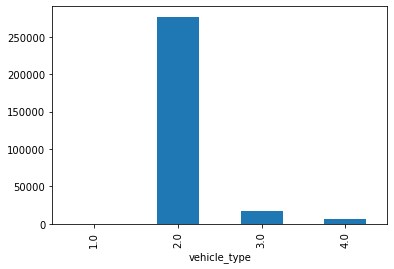

```python
vehicle_type_count = data.groupby('vehicle_type')['event_number'].count()
vehicle_type_count.plot(kind='bar')
```

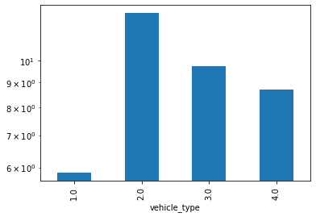

```python
vehicle_type_count_log.plot(kind='bar', logy=True)
```

**Matplotlib native**

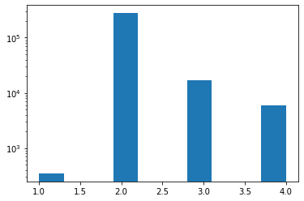

```python
fig, ax1 = plt.subplots() # prepare a matplotlib figure
ax1.hist(data.vehicle_type)
ax1.set_yscale('log')
```

This doesn't look so great yet

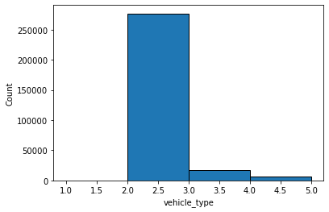

```python
fig, ax1 = plt.subplots()
bins = range(1, data.vehicle_type.nunique()+2)
ax1.hist(data.vehicle_type, bins=bins, edgecolor='black', linewidth=1)
ax1.set_xlabel('vehicle_type')
ax1.set_ylabel('Count')
```

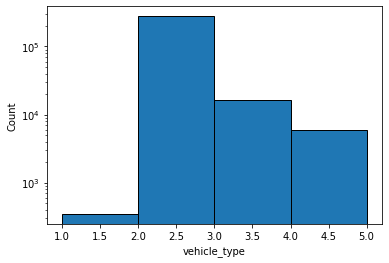

```python
fig, ax1 = plt.subplots()
ax1.hist(data.vehicle_type, bins=bins, edgecolor='black', linewidth=1)
ax1.set_yscale('log')
ax1.set_xlabel('vehicle_type')
ax1.set_ylabel('Count')
```

**Seaborn**

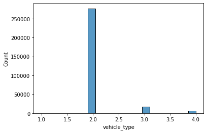

```python
sns.histplot(data=data, x='vehicle_type')
```

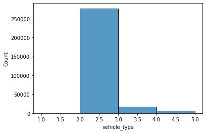

```python
sns.histplot(data=data, x='vehicle_type', bins=bins)
```

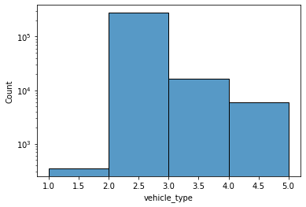

```python
sns.histplot(data=data, x='vehicle_type', bins=bins, log_scale=[False, True])
```

Let's look at the validity of entries per vehicle type. To do that we create a stacked bar plot, with validity (True or False) as the stacked variable. First we need a new variable for the total validity of an entry

```python
data['valid'] = data['valid_classification'] & data['valid_event'] &\
                data['valid_length'] & ['valid_speed']
data['valid'] = data['valid'].astype(int)
```

```python
vehicle_type_valid = data.groupby(['vehicle_type', 'valid'])['event_number'].count()
vehicle_type_valid
```

```
vehicle_type  valid
1.0           0           338
              1            11
2.0           0         78919
              1        197852
3.0           0          3732
              1         12951
4.0           0           984
              1          4956
Name: event_number, dtype: int64
```

```python
vehicle_type_valid_df = vehicle_type_valid.unstack()
```

**Pandas**

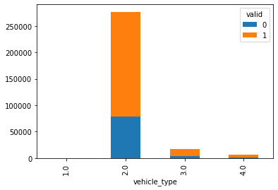

```python
vehicle_type_valid_df.plot(kind='bar', stacked=True)
```

**Matplotlib native**

See upcoming section on grouped bar plots

**Seaborn**

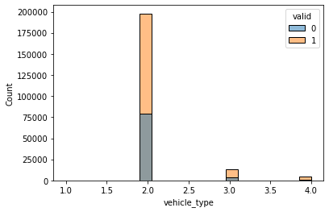

```python
sns.histplot(data=data, x='vehicle_type', hue='valid')
```

### Bar plots

A bar plot represents an estimate of central tendency for a numeric variable with the height of each rectangle and provides some indication of the uncertainty around that estimate using error bars. Bar plots include 0 in the quantitative axis range, and they are a good choice when 0 is a meaningful value for the quantitative variable, and you want to make comparisons against it.

**Pandas**

```python
speedbylane = data.groupby('lane').speed.mean()
```

```python
speedbylane_std = data.groupby('lane').speed.std()
```

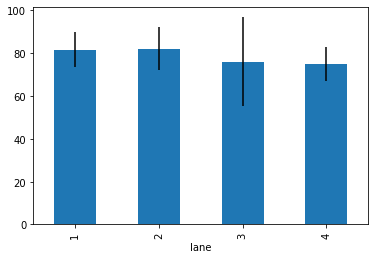

```python
speedbylane.plot(kind='bar', yerr=speedbylane_std)
```

**Matplotlib native**

```
<BarContainer object of 4 artists>
```

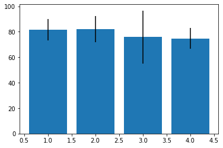

```python
fig, ax1 = plt.subplots() # prepare a matplotlib figure
ax1.bar(speedbylane.index, speedbylane, yerr=speedbylane_std)
```

**Seaborn**

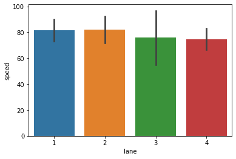

```python
sns.barplot(data=data, x='lane', y='speed', ci='sd')
```

### Scatterplot

A scatterplot is a type of data display that shows the relationship between two numerical variables. Each member of the dataset gets plotted as a point whose x-y coordinates relates to its values for the two variables.

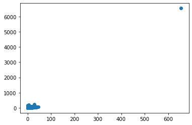

```python
fig, ax1 = plt.subplots() # prepare a matplotlib figure
ax1.scatter(data.length, data.speed)
```

Clearly there's a nonsensical outlier in the data

```python
data.length.max()
```

```
655.4
```

```python
data.length.idxmax()
```

```
245867
```

```python
data.speed.max()
```

```
6553.5
```

```python
data.speed.idxmax()
```

```
245867
```

```python
data = data.drop(data.speed.idxmax())
```

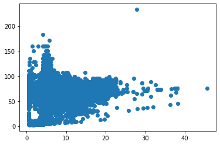

```python
fig, ax1 = plt.subplots() # prepare a matplotlib figure
ax1.scatter(data.length, data.speed)
```

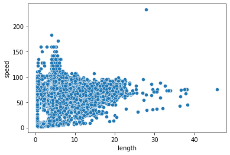

```python
fig, ax1 = plt.subplots() # prepare a matplotlib figure
ax1.scatter(data.length, data.speed, edgecolor='white', linewidth=0.5)
ax1.set_xlabel('length')
ax1.set_ylabel('speed')
```

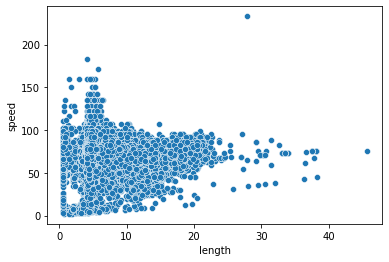

```python
sns.scatterplot(data=data, x='length', y='speed')
```

```python
vehicle_types = data.vehicle_type.unique()
colours = get_n_colours(5)
cmap = {vehicle_types[i]: colours[i] for i in range(5)}
cmap
```

[output not shown]

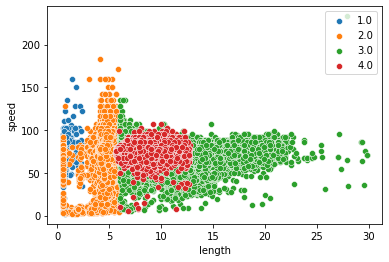

```python
data_grouped = data.groupby('vehicle_type')

fig, ax1 = plt.subplots() # prepare a matplotlib figure

for key, group in data_grouped:
    ax1.scatter(group.length, group.speed, edgecolor='white', linewidth=0.5, label=key)

ax1.set_xlabel('length')
ax1.set_ylabel('speed')
ax1.legend(loc='upper right')
```

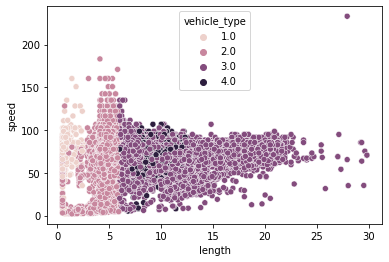

```python
sns.scatterplot(data=data, x='length', y='speed', hue='vehicle_type')
```

### Grouped bar plots

A grouped bar chart (aka clustered bar chart, multi-series bar chart) extends the bar chart, plotting numeric values for levels of two categorical variables instead of one. Bars are grouped by position for levels of one categorical variable, with color indicating the secondary category level within each group.

```python
data['valid'] = data['valid_classification'] & data['valid_event'] &\
                data['valid_length'] & ['valid_speed']
```

```python
x = np.arange(4)
x
```

```
array([0, 1, 2, 3])
```

```python
data.sem()['length']
```

```
0.003320126308455634
```

[output not shown]

[output cut: 25 more lines]

[output not shown]

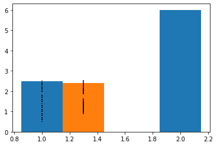

```python
import numpy as np

grouped_data = data.groupby('valid')
x = np.arange(5)
width = 0.3

fig, ax1 = plt.subplots() # prepare a matplotlib figure

for key, group in data_grouped:
    error_false = group[group['valid'] == False]['length'].sem()
    length_false = group['length'][group['valid'] == False]
    error_true = group[group['valid'] == True]['length'].sem()
    length_true = group['length'][group['valid'] == True]
    ax1.bar(key, length_false, width=width, color='tab:blue', yerr=error_false)
    ax1.bar(key+width, length_true, width=width, color='tab:orange', yerr=error_true)

ax1.set_xlabel('vehicle_type')
ax1.set_ylabel('length')
ax1.legend(loc='upper right')
```

```python
error_false
```

[output not shown]

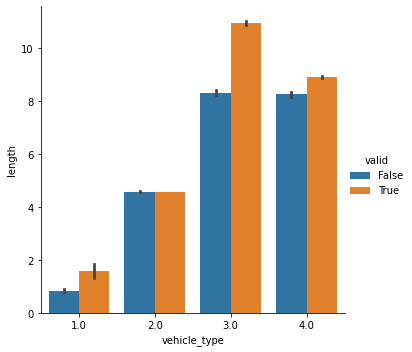

```python
sns.catplot(data=data, kind='bar', x='vehicle_type', y='length', hue='valid')
```

### Boxplots

a box plot or boxplot is a method for graphically demonstrating the locality, spread and skewness groups of numerical data through their quartiles. In addition to the box on a box plot, there can be lines (which are called whiskers) extending from the box indicating variability outside the upper and lower quartiles, thus, the plot is also termed as the box-and-whisker plot and the box-and-whisker diagram. Outliers that differ significantly from the rest of the dataset may be plotted as individual points beyond the whiskers on the box-plot.

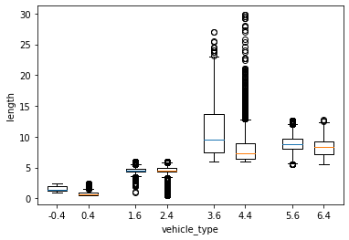

```python
data_grouped = data.groupby('vehicle_type')

fig, ax1 = plt.subplots() # prepare a matplotlib figure

group_true = []
group_false = []
for key, group in data_grouped:
    group_true.append(group['length'][group['valid'] == True])
    group_false.append(group['length'][group['valid'] == False])

bpt = ax1.boxplot(group_true, positions=np.array(range(len(group_true)))*2.0-0.4)
bpf = ax1.boxplot(group_false, positions=np.array(range(len(group_false)))*2.0+0.4)

plt.setp(bpt['medians'], color='tab:blue')
ax1.set_xlabel('vehicle_type')
ax1.set_ylabel('length')
#ax1.legend(loc='upper right')
```

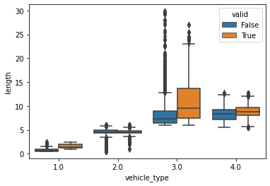

```python
sns.boxplot(data=data, x='vehicle_type', y='length', hue='valid')
```

### Distribution plot

A distribution plot, depicts the variation in the data distribution.

```python
data.columns
```

```
Index(['created_at_timestamp', 'event_emitted_timestamp', 'event_number',
       'event_timestamp', 'klokketime', 'lane', 'length', 'qspeed',
       'region_id', 'speed', 'time_gap', 'traffic_registration_point_id',
       'valid_classification', 'valid_event', 'valid_length', 'valid_speed',
       'vehicle_type', 'vehicle_type_raw', 'weight',
       'with_traffic_registration_point_direction', 'wrong_direction'],
      dtype='object')
```

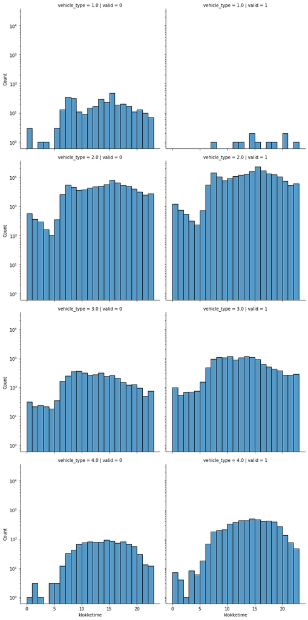

```python
sub = data[['klokketime', 'vehicle_type', 'valid']].copy()
sub['valid'] = sub['valid'].astype(int)
sns.displot(sub, x='klokketime', col='valid', row='vehicle_type', log_scale=[False, True], binwidth=1)
```

### Correlation heatmap

Used to visualise correlation between any variable with another (only numerical variables). Handy indicator for building predictive models.

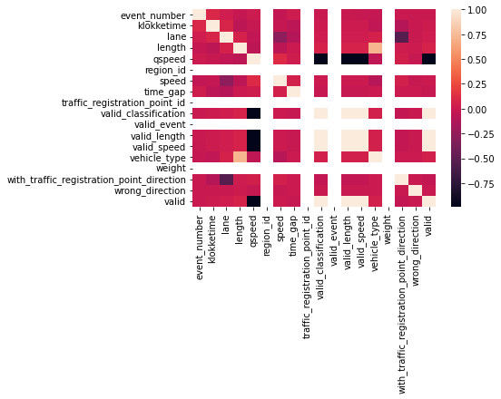

```python
corr = data.corr()
sns.heatmap(corr)
```